# Yeast Genetic Interactions Network

# 1 Genetic Interactions

A genetic interaction (GI) between two genes generally indicates that the phenotype of a double mutant differs from what is expected from each individual mutant. The existence of a GI between two genes does not necessarily imply that these two genes code for interacting proteins or that the two genes are even expressed in the same cell. In fact, a GI only implies that the two genes share a functional relationship. These two genes may be involved in the same biological process or pathway; or they may also be involved in compensatory pathways with unrelated apparent function [Genetic interaction networks: better understand to better predict]

# 2 Data

Here we will explore and analyse the GI network of yeast. Data were downloaded from [BIOGRID](https://thebiogrid.org/download.php) in December 2016 and were sorted by organism under the hyperlink: **BIOGRID-ORGANISM-3.4.143.tab2.zip**. We will use data from *Saccharomyces cerevisiae*. Files are in Tab2 format, so in order to import them in r, we first have to remove manually the text from the first part of the file.

The file from yeast contains many interactions. From them we have to retrieve the ones we are interested in, which are the ones resulting from [Synthetic Genetic Arrays](https://en.wikipedia.org/wiki/Synthetic_genetic_array).

```r
summary(yeast_BIOGRID$EXPERIMENTAL_SYSTEM)
```

```
## Affinity Capture-Luminescence           Affinity Capture-MS
##                            50                         58455
##          Affinity Capture-RNA      Affinity Capture-Western
##                         11166                         16569
##          Biochemical Activity          Co-crystal Structure
##                          6650                           881
##              Co-fractionation               Co-localization
##                           975                           675
##               Co-purification          Dosage Growth Defect
##                          4326                          1988
##              Dosage Lethality                 Dosage Rescue
##                          1627                          5663
##                   Far Western                          FRET
##                           101                           219
##              Negative Genetic                           PCA
##                        115467                          6577
##        Phenotypic Enhancement        Phenotypic Suppression
##                          7487                          6590
##              Positive Genetic               Protein-peptide
##                         24681                           846
##                   Protein-RNA         Reconstituted Complex
##                           573                          7657
##       Synthetic Growth Defect  Synthetic Haploinsufficiency
##                         25200                           283
##           Synthetic Lethality              Synthetic Rescue
##                         16217                          6905
##                    Two-hybrid
##                         15973
```

These are

- Negative: **Synthetic Lethality** and **Negative Genetic**
- Positive: **Synthetic Rescue** and **Positive Genetic**

## 2.1 Extract GIN

**Synthetic Lethality** means that the second mutation is lethal. **Negative Genetic** means that the phenotype of the two mutations is worse than expected. **Synthetic Rescue** means that even though the first mutation is leathal, the second mutation regains the viability of the organism. **Positive Genetic** means that the phenotype is better (highest fitness) than expected.

```r
yeast_GIN <- subset(x = yeast_BIOGRID, EXPERIMENTAL_SYSTEM=="Synthetic Lethality" | EXPERIMENTAL_SYSTEM=="Negative Genetic" | EXPERIMENTAL_SYSTEM=="Synthetic Rescue" | EXPERIMENTAL_SYSTEM=="Positive Genetic")
yeast_GIN$weights <- with(yeast_GIN, ifelse(EXPERIMENTAL_SYSTEM=="Synthetic Lethality" | EXPERIMENTAL_SYSTEM=="Negative Genetic", -1, 1))

rm(yeast_BIOGRID)

summary(yeast_GIN$EXPERIMENTAL_SYSTEM)
```

```
## Affinity Capture-Luminescence           Affinity Capture-MS
##                             0                             0
##          Affinity Capture-RNA      Affinity Capture-Western
##                             0                             0
##          Biochemical Activity          Co-crystal Structure
##                             0                             0
##              Co-fractionation               Co-localization
##                             0                             0
##               Co-purification          Dosage Growth Defect
##                             0                             0
##              Dosage Lethality                 Dosage Rescue
##                             0                             0
##                   Far Western                          FRET
##                             0                             0
##              Negative Genetic                           PCA
##                        115467                             0
##        Phenotypic Enhancement        Phenotypic Suppression
##                             0                             0
##              Positive Genetic               Protein-peptide
##                         24681                             0
##                   Protein-RNA         Reconstituted Complex
##                             0                             0
##       Synthetic Growth Defect  Synthetic Haploinsufficiency
##                             0                             0
##           Synthetic Lethality              Synthetic Rescue
##                         16217                          6905
##                    Two-hybrid
##                             0
```

The bar plot of the 4 types of relations.

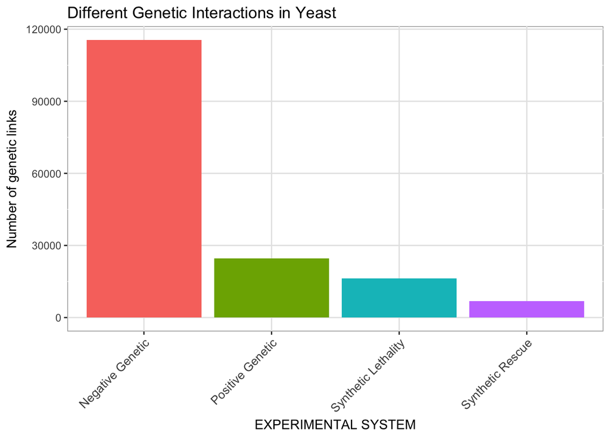

```r
ggplot()+
  geom_bar(data = yeast_GIN, aes(EXPERIMENTAL_SYSTEM, y= ..count.., fill=EXPERIMENTAL_SYSTEM),show.legend = F)+
  ggtitle("Different Genetic Interactions in Yeast")+
  labs(x="EXPERIMENTAL SYSTEM", y= "Number of genetic links")+
  theme(panel.grid.major = element_line(colour = "grey90"), panel.background = element_rect(fill = "white", colour = "grey60"),
        axis.text.x = element_text(size  = 10, angle = 45,hjust = 1,vjust = 1))
```

## 2.2 Duplicates and sign consistency

We check for the unique links.In order to check this we first concatenate the node IDs for each link and then we check for uniqueness.

```r
yeast_GIN$links <- with(yeast_GIN,paste(yeast_GIN$INTERACTOR_A,yeast_GIN$INTERACTOR_B,sep = ",")) # concarnate in order to find duplicated links
length(unique(yeast_GIN$links)) # how many unique links
```

```
## [1] 144166
```

But the number of links is:

```r
nrow(yeast_GIN)
```

```
## [1] 163270
```

So there are 19104 duplicates. Next we want to label each link to see if it’s duplicated and after that we count the duplicates of each link in order to find the origin of the duplicates.

```r
yeast_GIN$duplicate <- duplicated(yeast_GIN$links) | duplicated(yeast_GIN$links, fromLast = TRUE) # returns TRUE for all duplicates, not the first ones only

yeast_GIN_dublicates <- subset(x = yeast_GIN, yeast_GIN$duplicate==TRUE)
# count the number of occurences of each link
GIN_occurences <- yeast_GIN %>%
  group_by(links) %>%
  summarise (n = n())

#summary(GIN_occurences)
```

```r
GIN_occurences$link <- c(seq(1:length(GIN_occurences$links)))
GIN_dupl_freq<-aggregate(rep.int(1, length(GIN_occurences$link))~GIN_occurences$n, FUN=sum)
names(GIN_dupl_freq)<-c("Copies per link","Count of links")
kable(GIN_dupl_freq, align = 'c', caption = "The number of copies of each link in the data yeast GIN")
```

The number of copies of each link in the data yeast GIN

| Copies per link | Count of links |
| --- | --- |
| 1 | 129604 |
| 2 | 11381 |
| 3 | 2331 |
| 4 | 593 |
| 5 | 148 |
| 6 | 55 |
| 7 | 25 |
| 8 | 8 |
| 9 | 8 |
| 10 | 2 |
| 11 | 5 |
| 12 | 2 |
| 13 | 1 |
| 14 | 1 |
| 16 | 2 |

So some links appear multiple times. The link between YCR066W and YJL092W appears 16 times in the dataset. This is due to the different sources which discoved an already known genetic relation. Next we have to delete duplicates. In order to do so we have to examine the nature of the genetic interaction for each duplicate. If between duplicates there are contradictions of the sign of the genetic interaction we have to delete the interaction. If not, we’ll keep one version of the interaction.

```r
## duplicated links

#sort links so the duplicates are adjacent?
duplicated_interactions <- yeast_GIN_dublicates[order(yeast_GIN_dublicates$links),]
#yeast_GIN2 <- head(duplicated_interactions,n = 200)
yeast_GIN_unique_dup <- as.data.frame(matrix())
yeast_GIN_unique_dup <- as.data.frame(unique(duplicated_interactions$links))
yeast_GIN_unique_dup2 <- as.data.frame(yeast_GIN_unique_dup)

ptm <- proc.time()
for(i in 1:nrow(yeast_GIN_unique_dup)){

  tmp_dupl_links <- subset(yeast_GIN_dublicates,yeast_GIN_dublicates$links==yeast_GIN_unique_dup[i,])

  if (abs(sum(tmp_dupl_links$weights))==nrow(tmp_dupl_links)){

    yeast_GIN_unique_dup2[i,2] <- "consistent"
    #print(paste0("consistent ",yeast_GIN_unique_dup[i,1]))

    } else {
      yeast_GIN_unique_dup2[i,2] <- "inconsistent"
      #print(paste("inconsistent ",yeast_GIN_unique_dup[i,1]))
    }

  yeast_GIN_unique_dup2[i,3] <- length(which(tmp_dupl_links$weights>0))#Positive_Interactions
  yeast_GIN_unique_dup2[i,4] <- length(which(tmp_dupl_links$weights<0)) #Positive_Interactions
  tmp_dupl_links <- c()

}

colnames(yeast_GIN_unique_dup2) <- c("Dublicated_Interactions","Consistency","Positive_Interactions", "Negative_Interactions")
proc.time() - ptm
```

```
##    user  system elapsed
##  42.970   7.807  51.905
```

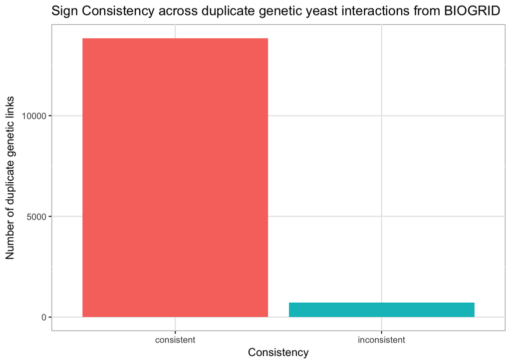

```r
#consistency
ggplot()+
  geom_bar(data = yeast_GIN_unique_dup2, aes(Consistency, y= ..count.., fill=Consistency),show.legend = F)+
  ggtitle("Sign Consistency across duplicate genetic yeast interactions from BIOGRID")+
  labs(x="Consistency", y= "Number of duplicate genetic links")+
  theme(panel.grid.major = element_line(colour = "grey90"), panel.background = element_rect(fill = "white", colour = "grey60"))
```

```r
count_consistency_GIN <- yeast_GIN_unique_dup2 %>%
  group_by(Consistency) %>%
  summarise (n = n())


kable(count_consistency_GIN, align = 'c', caption = "Sign consistency across duplicated genetic interactions in yeast GIN")
```

Sign consistency across duplicated genetic interactions in yeast GIN

| Consistency | n |
| --- | --- |
| consistent | 13844 |
| inconsistent | 718 |

Next we have to keep only the unique interactions and remove the inconsistent interactions from the original dataset.

```r
ddd <- subset(yeast_GIN_unique_dup2,yeast_GIN_unique_dup2$Consistency=="inconsistent")

yeast_GIN$Consistency <- !(yeast_GIN$links %in% ddd$Dublicated_Interactions)
yeast_GIN$duplicate_not_first <- duplicated(yeast_GIN$links)
yeast_GIN_final <- subset(yeast_GIN, yeast_GIN$duplicate_not_first==FALSE)
yeast_GIN_final <- subset(yeast_GIN_final, yeast_GIN_final$Consistency==TRUE)


nrow(yeast_GIN_final)==length(unique(yeast_GIN_final$links)) # check unique links
```

```
## [1] TRUE
```

```r
nrow(yeast_GIN_final)
```

```
## [1] 143448
```

```r
a <- as.character(yeast_GIN_final$INTERACTOR_A)
b <- as.character(yeast_GIN_final$INTERACTOR_B)
yeast_GIN_genes <- as.data.frame(unique(c(a,b)))
yeast_GIN_genes <- yeast_GIN_final$INTERACTOR_B #as.factor(yeast_GIN_final$INTERACTOR_B))

nrow(yeast_GIN_genes)
```

[output not shown]

The removal of duplicates and the complete deletion of links with duplicates and inconsistent signs leads to the final edgelist. The final edgelist of yeast GIN consists of **143448** interactions and **5433** genes.

```r
count_weights_GIN <- yeast_GIN_final %>%
  group_by(weights) %>%
  summarise (n = n())


kable(count_weights_GIN, align = 'c', caption = "Weight frequences of the yeast GIN")
```

Weight frequences of the yeast GIN

| weights | n |
| --- | --- |
| -1 | 114864 |
| 1 | 28584 |

## 2.3 Loops

Next, we need to examine if there are any loops in the network. Which means that we have to look for interactions that have the same gene in edge list.

```r
loop_finder <- function(x){
  d<- c()
  for(i in 1:nrow(x)){

    if(as.character(x[i,1])==as.character(x[i,2])){
      d <- c(d,as.character(x[i,1]))
    }else{}
  }
    d <-as.data.frame(d)
    colnames(d)[1]<-"genes_loop"
    d
  }
loops <- loop_finder(yeast_GIN_final)
nrow(loops)
```

```
## [1] 8
```

There are 8 loops in the yeast GIN. What do they mean? Do they have biological meaning?

# 3 Network analysis

Import the network in igraph. We choose to delete the loops (8).

```r
library(igraph)

yeast_GIN_Net <- as.data.frame(yeast_GIN_final[,-c(3:11,13:16)])
g_yeast_GIN <- graph_from_data_frame(yeast_GIN_Net,directed = T)
summary(g_yeast_GIN)
```

```
## IGRAPH DN-- 5433 143448 --
## + attr: name (v/c), weights (e/n)
```

```r
is.simple(g_yeast_GIN)
```

```
## [1] FALSE
```

```r
#It has multiple links?
E(g_yeast_GIN)$multiple <- which_multiple(g_yeast_GIN)
summary(E(g_yeast_GIN)$multiple) # all FALSE
```

```
##    Mode   FALSE    NA's
## logical  143448       0
```

```r
# It has loops?
E(g_yeast_GIN)$loop <- which_loop(g_yeast_GIN)
summary(E(g_yeast_GIN)$loop) # 8 TRUE loops
```

```
##    Mode   FALSE    TRUE    NA's
## logical  143440       8       0
```

```r
#Remove loops
g_yeast_GIN <- igraph::simplify(g_yeast_GIN)
# Assign attributes
yeast_GIN_Net$sign_color <- with(yeast_GIN_Net, ifelse(weights<0, paste0("red"), paste0("blue")))
E(g_yeast_GIN)$weights <- yeast_GIN_Net$weights
E(g_yeast_GIN)$sign_color <- yeast_GIN_Net$sign_color
is.simple(g_yeast_GIN)
```

```
## [1] TRUE
```

```r
summary(g_yeast_GIN)
```

```
## IGRAPH DN-- 5433 143440 --
## + attr: name (v/c), weights (e/n), sign_color (e/c)
```

Create the adjacency matrix.

```r
adjacency_weight_yeast_GIN <- as_adjacency_matrix(g_yeast_GIN, attr = "weights",names = T)
adjacency_weight_yeast_GIN <- as.data.frame(as.matrix(adjacency_weight_yeast_GIN))
sum(sapply(adjacency_weight_yeast_GIN,is.character)) # if 0 then there are no characters inside dataframe!
```

```
## [1] 0
```

```r
#write.table(adjacency_weight_yeast_GIN,file = "adjacency_matrix_yeast_GIN.txt",sep = "\t",row.names = T,col.names = T) # the file of the adjacency matrix.
```

To make further calculations we isolate the giant component.

```r
igraph::is.connected(g_yeast_GIN)
```

```
## [1] FALSE
```

```r
decg<-decompose.graph(g_yeast_GIN, min.vertices = 10) #upografima tis megalis sinistosas
gcomp_GIN<-decg[[1]]
igraph::is.connected(gcomp_GIN)
```

```
## [1] TRUE
```

```r
summary(gcomp_GIN)
```

```
## IGRAPH DN-- 5422 143431 --
## + attr: name (v/c), weights (e/n), sign_color (e/c)
```

Only 11 genes and 9 links weren’t connected with the giant component.

## 3.1 Degree distribution

One of the first things to examine is the degree distribution of the graph.

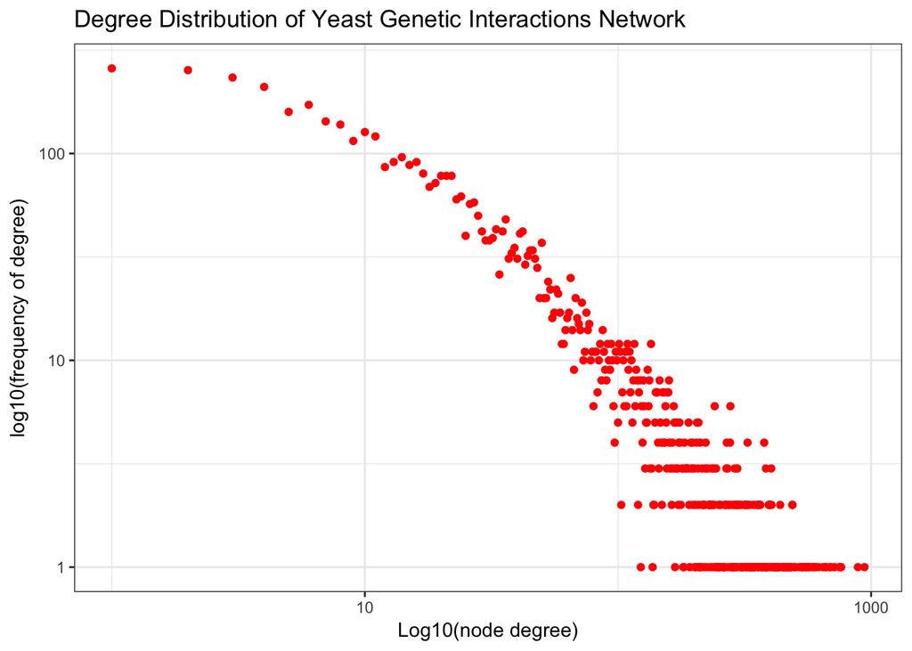

```r
# Degree distribution of the graph

de <- igraph::degree(gcomp_GIN)
de <- as.data.frame(de)
de$node <- c(seq(1:length(de$de)))
dd<-aggregate(rep.int(1, length(de$node))~de$de, FUN=sum)
names(dd)<-c("val","freq")

ggplot()+
  geom_point(data = dd, aes(x = val,y = freq ),color="red")+
  scale_y_log10()+
  scale_x_log10()+
  ggtitle("Degree Distribution of Yeast Genetic Interactions Network")+
  labs(x="Log10(node degree)", y="log10(frequency of degree)")+
  theme_bw()
```

Plot of the network.

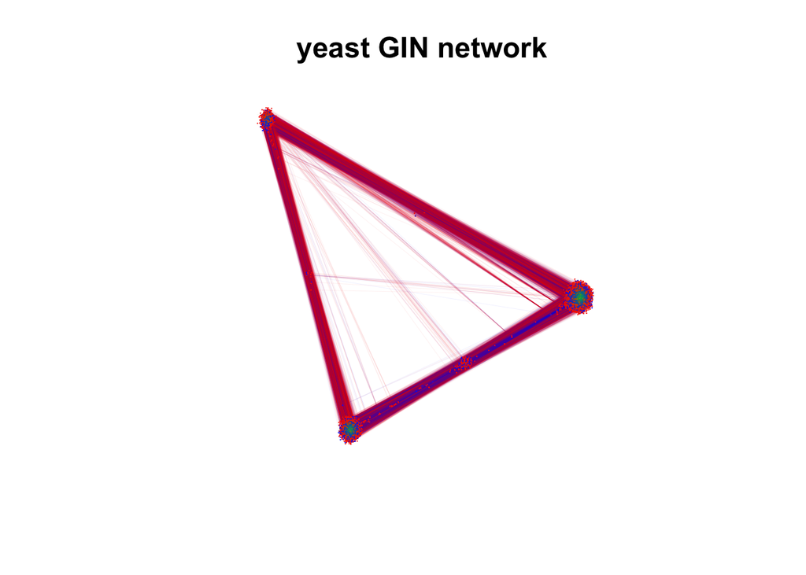

```r
layg <- layout_nicely(gcomp_GIN)
V(gcomp_GIN)$coord1 <-layg[ ,1]     ## network plots
V(gcomp_GIN)$coord2 <-layg[ ,2]

plot(gcomp_GIN,
     layout=layg,
     vertex.shape="circle",
     vertex.size=0.0095,
     vertex.color="green",
     vertex.frame.color="green",
     vertex.label=NA,
     #vertex.label.cex = vcount(g)*0.00004,
     #vertex.label.color ="black",
     edge.color=E(gcomp_GIN)$sign_color,
     edge.width=0.03,
     edge.arrow.size = 0.00001,
     edge.arrow.width = 0.0000005,
     #edge.label=round(x = E(g)$weight,digits = 3),
     #edge.label.cex = 0.3,
     #edge.label.color = E(g)$color,
     margin = 0,
     main = "",
     sub = "")
title(main = paste("yeast GIN network "), cex.main= 1.5, cex.sub = 1.2,outer = F)
```

```r
#sss <- induced_subgraph(gcomp_GIN, v = nei[[1]])

#plot(sss,edge.color=E(gcomp_GIN)$sign_color)

#nei <- neighborhood(gcomp_GIN,order = 1,nodes = "YOL001W")

yeast_GIN_final$AD <- paste0(yeast_GIN_final[,1],",",yeast_GIN_final[,12])
yeast_GIN_final$BD <- paste0(yeast_GIN_final[,2],",",yeast_GIN_final[,12])

AD_freq <- table(yeast_GIN_final$AD)
AD_freq <- as.data.frame(AD_freq)
BD_freq <- table(yeast_GIN_final$BD)


AD_freq_a <- strsplit(as.character(AD_freq$Var1),split = ",")
AD_freq_a <- as.data.frame(AD_freq_a)
AD_freq_a <- t(AD_freq_a)

AD_freq$gene <- AD_freq_a[,1]
AD_freq$weight <- AD_freq_a[,2]

AD_freq_a_1 <- AD_freq[order(AD_freq$weight,AD_freq$Freq,decreasing = T),]
AD_freq_a_neg <- subset(x = AD_freq_a_1,AD_freq_a_1$weight==-1)
#AD_freq_a_1 <- AD_freq[order(AD_freq$Freq,decreasing = T),]
```